# Estudio sobre la empleabilidad en Lima Metropolitana en el primer trimestre del año 2021

07/08/2021

[figure not shown]

### Introducción

##### Importancia y Justicación

La situación que se está viviendo en nuestro país a causa del COVID 19 está ocasionando efectos negativos sin precedentes en muchos sectores del Perú, ya sea en el sector sanitario, social y en la misma economía. Además, es en este último es donde existe un gran número de personas que se han visto afectadas en sus ingresos, calidad y horas de trabajo, incluso en el desempleo. Por ello, en este estudio se analizará los indicadores sobre el mercado laboral, empleo e ingresos de las personas mayores de 14 años en el área Metropolitana de Lima en el trimestre de enero, febrero y marzo del 2021.

### Objetivos

1.**Objetivo Principal**

Determinar la situación de empleabilidad de las personas de Lima Metropolitana en el trimestre de enero, febrero y marzo del 2021.

1.1 **Objetivos Específicos**

- Analizar los indicadores de empleabilidad mediante el uso gráficos estadísticos
- Determinar el factor más relevante de la causa de desempleo
- Estimar la tasa de desempleo para los siguientes trimestre móviles
- Plantear opciones para disminuir la tasa de desempleo en Lima Metropolitana
- Conocer la situación económica y laboral de las personas en base a los indicadores de su ocupación durante el periodo trimestral enero, febrero y marzo del 2021.
- Relacionar el contexto de empleabilidad durante la pandemia de los ciudadanos en relación con los indicadores de empleabilidad de la encuesta y posteriormente servir como fuente de investigación, comparación y análisis para los futuros escenarios de empleabilidad durante los próximos trimestres.

### Factibilidad

La siguiente es una tabla que detalla las características y objetivos de cada entrega para cumplir con los requisitos de estas. Se detalla la fecha de publicación de la tarea, el tiempo hábil para completarla, y la fecha de entrega de cada una.

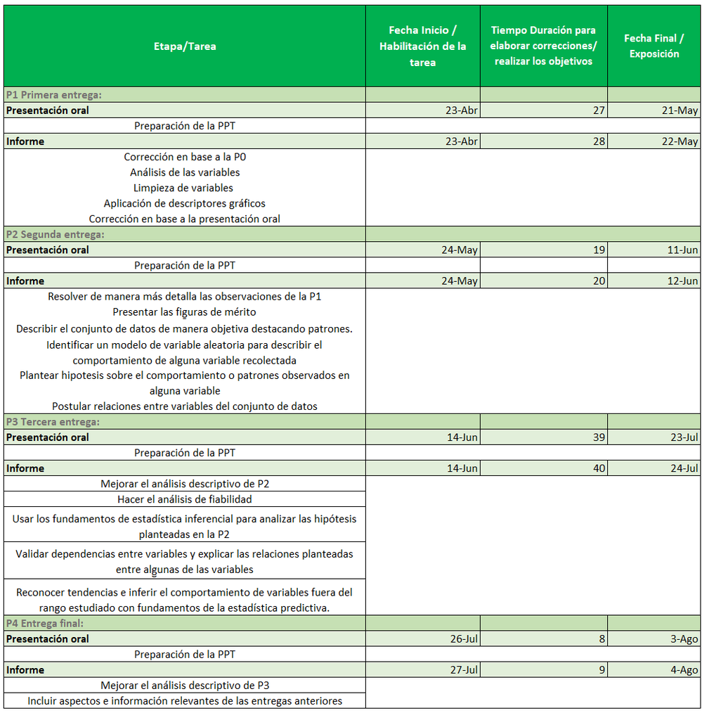

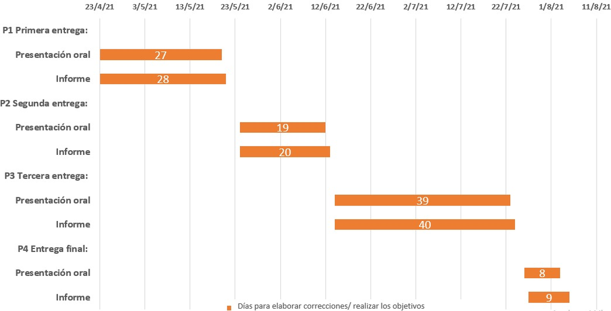

### Marco Teórico

Nuestro estudio se realizará con una base pública. Por ello, utilizaremos los datos proporcionados por la entidad estatal oficial del gobierno del Perú, el INEI. Estos datos fueron recogidos en los meses de enero, febrero y marzo del 2021. La organización estatal ha puesto estos datos de forma pública para poner en conocimiento la situación de empleabilidad de los ciudadanos y ayudar a otras organizaciones con fines investigativos al proporcionar datos de posible comparación o análisis. El muestreo del estudio fue hecho por conglomerados, como menciona la ficha técnica del estudio del INEI. De cada conglomerado se encuestó a un número determinado de viviendas y a las personas de 14 años o mayores encontradas en la vivienda.

#### Población Objetivo

1. La población bajo estudio está constituida por los habitantes mayores de 14 años en el Área Metropolitana de Lima. Según la encuesta realizada por el INEI, excluye del estudio a los miembros de las fuerzas armadas que viven en cuarteles, campamentos, barcos etc. Además, se excluye a las viviendas colectivas (hoteles, hospitales, asilos, claustros religiosos, cárceles etc.). Se recalca esto ya que la encuesta se hizo por viviendas, sin embargo nuestro enfoque es hacia las personas individuales.

#### Unidad muestral

2. Persona de 14 años o mayor habitante de Lima Metropolitana.

#### Variables y su definición

### **Numéricas (16)**

| **Variable** | **Definición** |
| --- | --- |
| p108 | Edad |
| p208b3 | Años trabajando en ocupación principal |
| p209a | Horas trabajadas el domingo la semana pasada |
| p209b | Horas trabajadas el lunes la semana pasada |
| p209c | Horas trabajadas el martes la semana pasada |
| p209d | Horas trabajadas el miércoles la semana pasada |
| p209e | Horas trabajadas el jueves la semana pasada |
| p209f | Horas trabajadas el viernes la semana pasada |
| p209g | Horas trabajadas el sábado la semana pasada |
| p209t | Horas totales trabajadas la semana pasada |
| p209cc | Horas semanales usuales |
| fa_efm21 | Factor de expansión |
| IMTdep | Ingreso total mensual de trabajo dependiente |
| IMTindep | Ingreso total mensual de trabajo independiente |
| IMTOSec | Ingreso total mensual de trabajo secundario |
| ITotal | Ingreso total mensual |

### **Categóricas (15)**

#### **Ordinales (2)**

| **Variable** | **Definición** |
| --- | --- |
| pmes | Mes de la encuesta |
| p109a | Nivel educativo alcanzado |

#### **Nominales (13)**

| **Variable** | **Definición** |
| --- | --- |
| p107 | Sexo del entrevistado |
| p206 | Trabajo principal |
| p209bb | Validación de horas semanales usuales y de la semana pasada |
| p209h | Voluntad de trabajar |
| p209ee | Si actualmente busca trabajo |
| p223a1 | Discapacidad: Dificultad para moverse |
| p223a2 | Discapacidad: Ciego |
| p223a3 | Discapacidad: Mudo |
| p223a4 | Discapacidad: Sordo |
| p223a5 | Discapacidad: Déficit de Atención |
| p223a6 | Discapacidad: Dificultades sociales |
| p223a7 | Tiene o no tiene alguna discapacidad |
| p204 | Clasificación de empleo fijo, sin empleo pero realizando actividades, y sin empleo ni actividades |

### Limpieza del Data Frame

#### Consideraciones para la eliminación de las variables

Las consideraciones establecidas fueron:

- Información sin sentido
- Información irrelevante para el estudio
- Información por número de NA’s
- Falta de claridad de la información

#### Variables de estudio

En un inicio la data del INEI contenía 103 variables, pero luego de aplicar la selección de variables se rescataron 31 variables.

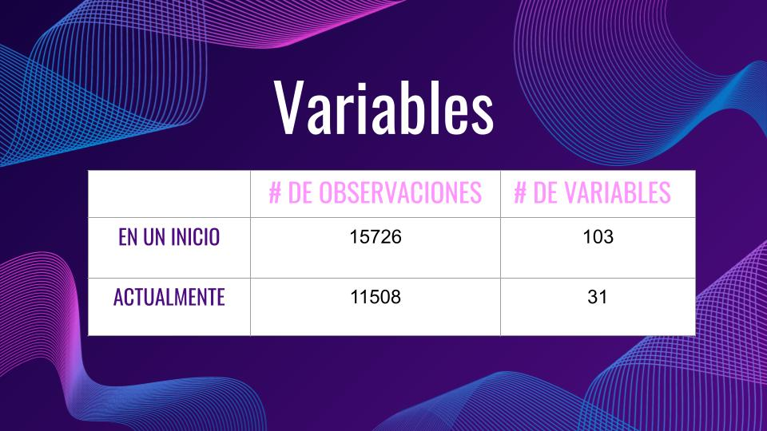

Se utilizó el R Notebook llamado *limpieza.Rmd* para limpiar el Data Frame y producir el nuevo “Data Limpia”. Este archivo se encuentra en el zip, ya que de esta manera es más ordenada la presentación del resto de la información en este documento y así logramos ser transparentes con el proceso de limpieza del DataFrame original producido mediante la encuesta del INEI.

**Preguntas e Hipótesis**

[output not shown]

#### Variables Cuantitativas

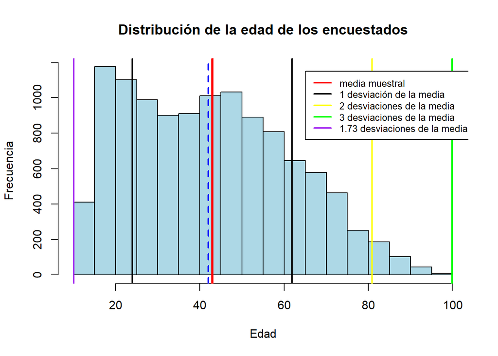

En la gráfica se muestra la distribución de las personas encuestadas según su edad. Se encuestaron personas de 14 a 98 años. De manera visual, podemos observar que la gráfica tiene un sesgo hacia la derecha por la cola larga en el lado derecho, y esto se afirma pues la mediana (42) es menor que la media (42.93), por ende, la distribución de esta variable no es simétrica, sino que se concentra hacia la izquierda. Interpretando, existe un número mayor de personas que tienen menos de 43 años a diferencia de las personas de mayor a esta edad. Asimismo, mediante la desviación estándar con respecto a la media, analizamos que tan dispersa se encuentra la muestra según su edad. Obtenemos que con una desviación tenemos una concentración de 61.94% de los datos; con dos tenemos el 97.05% y mientras que con tres desviaciones alcanzamos el 100%. Además, considerando que la edad es una variable cuantitativa discreta que va de 0 hasta aproximadamente 100 años y que la muestra abarca 84 de estos 100 años, concluimos que los datos están dispersos.

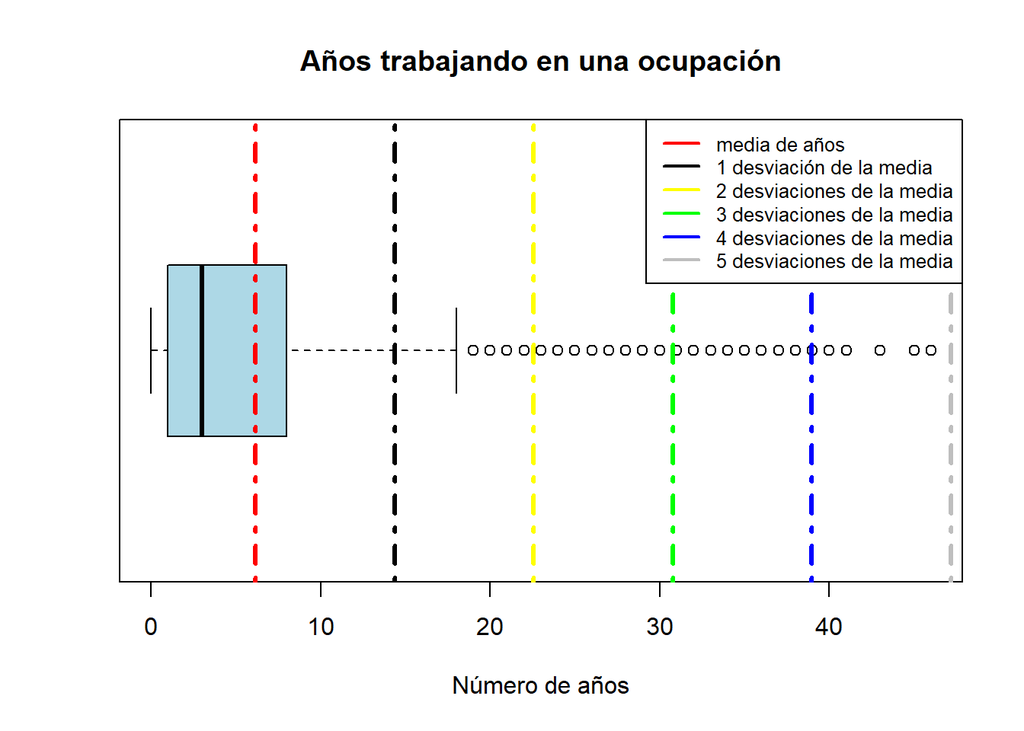

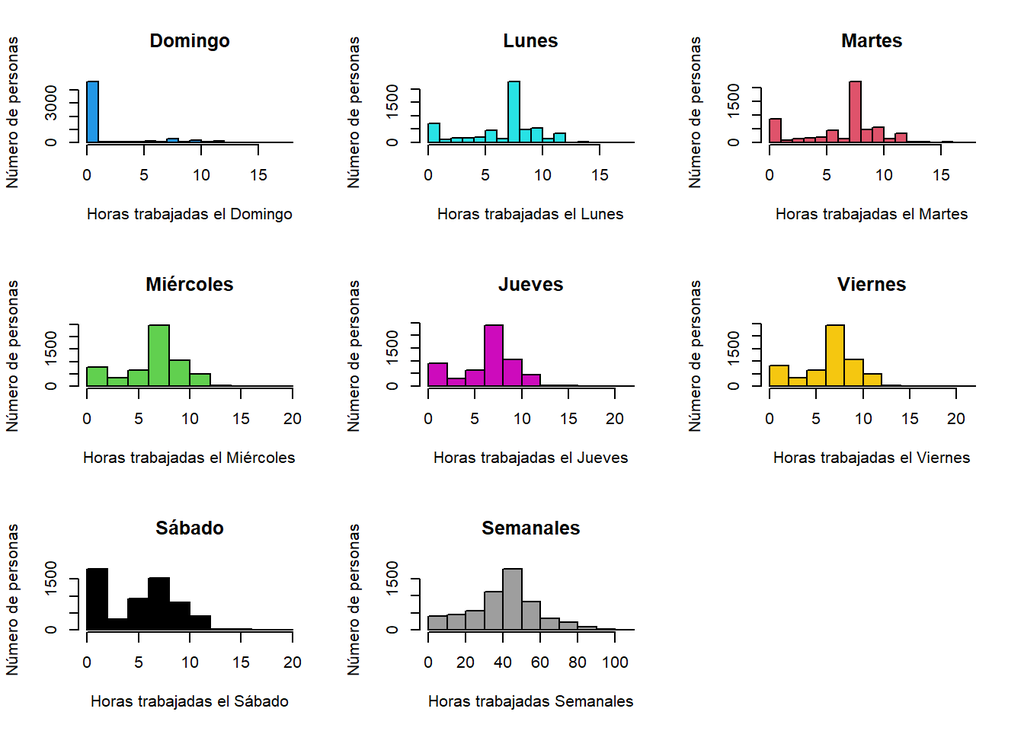

p209a, p209b, p209c, p209d, p209e, p209f, p209g, p209t: La mayor cantidad de encuestados no trabaja los domingos y muchos no trabajan los sábados. Tenemos un rango alto de horas trabajadas en cada día de la semana y en las horas semanales trabajadas, pues las personas de la muestra tienen trabajos muy variados. Asimismo, el mínimo de 0 horas trabajadas la semana pasada se interpreta como dato ingresado por las personas que la semana pasada estuvieron de descanso. A partir de los gráficos, se refuerza la idea de la tendencia a trabajar menor horas durante el fin de semana.

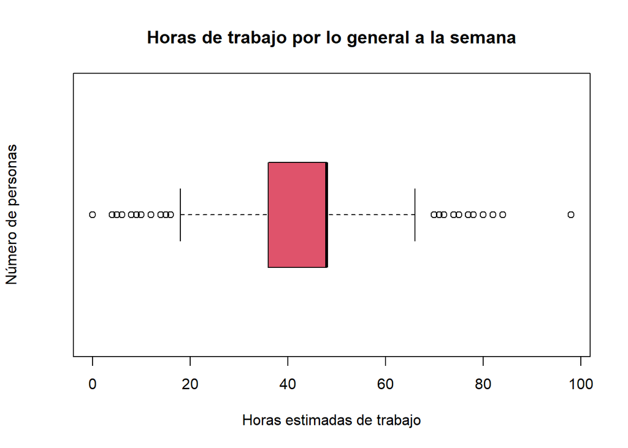

p209cc: Según la moda, más personas trabajan 48 horas semanales usualmente, esto coincide con la mediana (48), mas no con la media (42.31). La media es menor así que esta distribución estaría sesgada hacia la izquierda. Esto significa que hay más datos sobre la media que bajo la misma.

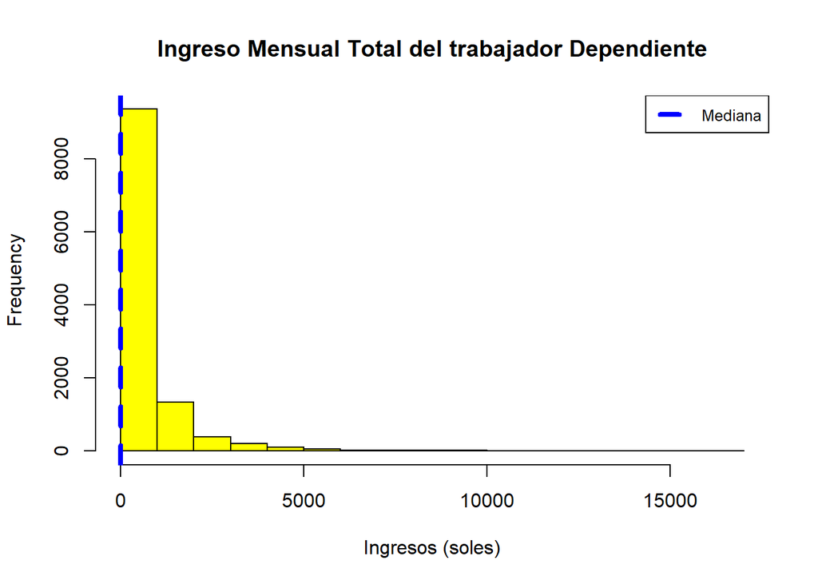

IMTdep: El ingreso dependiente que más se repitió entre los encuestados fue que no tienen ingreso mensual y la mediana indica que la mitad tampoco reciben un ingreso mensual. Tendremos un rango de 17 000 soles. Este es grande, por lo que la media se vería afectada. El rango intercuartílico es de 672 soles. Por ende, podemos inferir que los datos están concentrados. La razón por la que tantas personas no tienen un ingreso mensual de trabajador dependiente se puede deber a que están desempleados o no son empleados fijos.

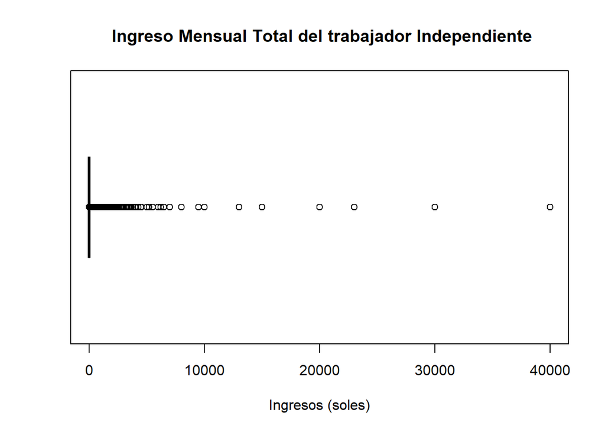

IMTindep: El IQR es 0, por lo tanto, la mayoría de los encuestados no tienen un ingreso mensual independiente. Al ser el mínimo, la moda, el IQR y la mediana cero, es evidente que el valor de la media está afectado, ya que el máximo es un valor muy alto.

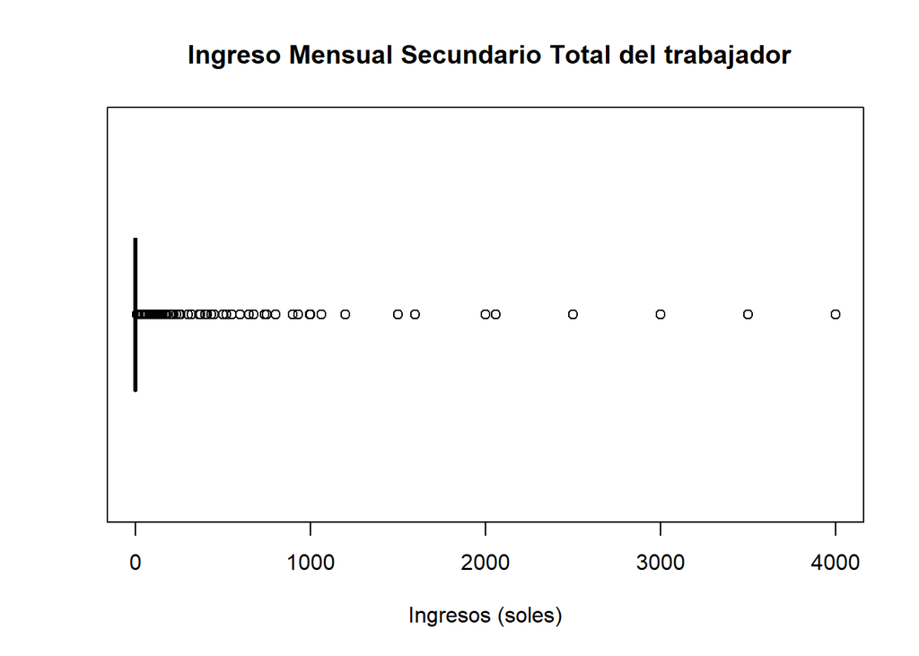

IMTOSec: Se presenta una tendencia parecida a la variable IMTindep, pero en este caso la media se verá menos afectada, ya que el máximo es considerablemente menor que en la variable anterior. A partir del gráfico se evidencia que el 50% de los entrevistados tiene alrededor de cero soles de ingreso mensual por una actividad secundaria. Debido a esta gran tendencia a no ganar ingresos en este ámbito laboral, los datos al extremo superior se interpretan como datos atípicos según el boxplot.

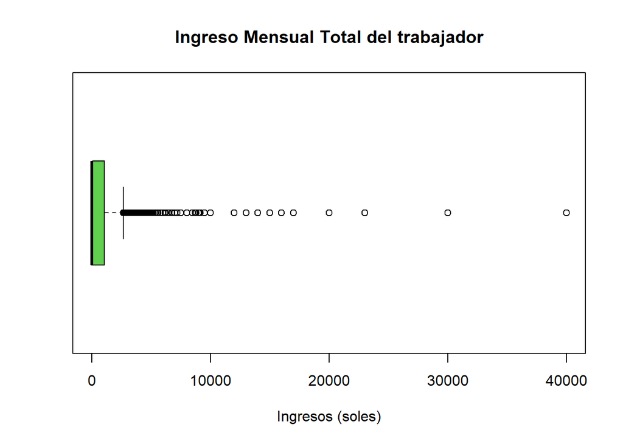

ITotal: El ingreso total es la suma de los tres ingresos: dependiente, independiente y secundario. El ingreso total que más se repitió entre los encuestados fue que no tienen ingreso mensual. El ingreso mensual total se presenta de mejor manera que las variables de ingreso dependiente, independiente y secundario por separado, debido a que la caja de este boxplot incluye más de un valor, no solo cero como las anteriores. El rango de los datos es grande, por lo que la presentación horizontal del boxplot sirve para mostrar de manera ordenada el rango completo de la data.

#### Variables Cualitativas

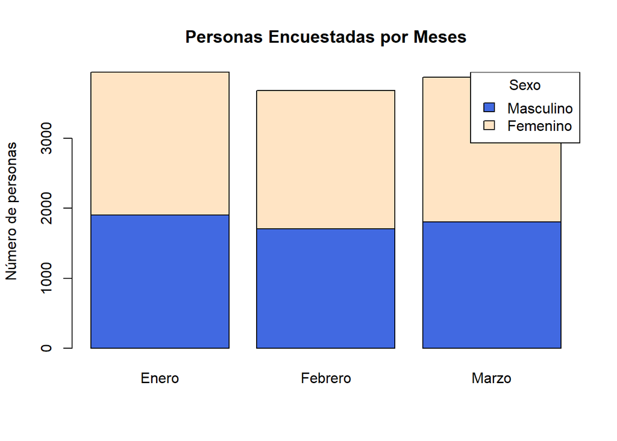

pmes: Esta variable nos permite conocer el mes en que se le realizó la encuesta a cada una de las personas. Esta se divide en tres meses: enero, febrero y marzo, pues es el trimestre que analizamos. Podemos ver que se encuestó a un número similar de personas en cada mes.

p107: Podemos identificar la cantidad de hombres y mujeres encuestados. La proporción entre hombres y mujeres en la muestra es similar a la población de Lima Metropolitana, siendo casi 50% cada uno pero un poco más de mujeres que hombres. La gráfica comprueba el análisis hecho anteriormente sobre la variable sexo.

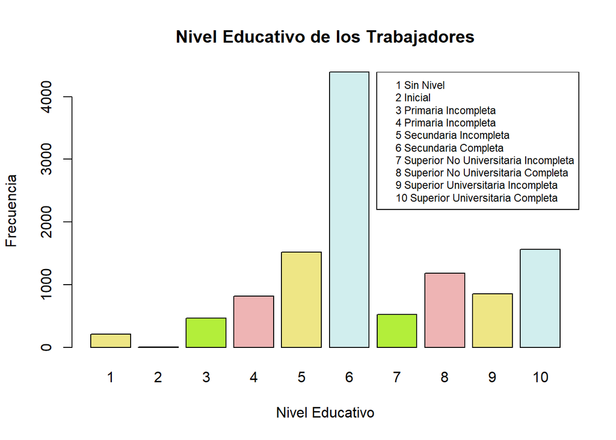

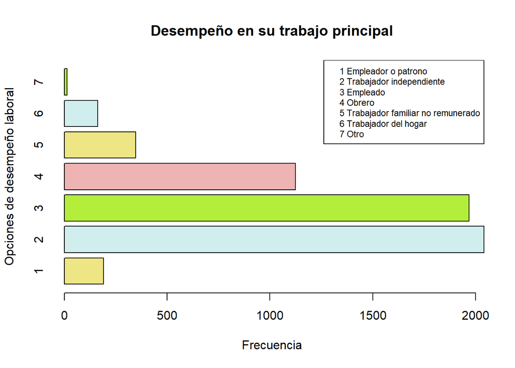

Esta gráfica nos muestra cuál es el desempeño del trabajador en su ocupación principal o negocio. Para ello, se presenta un conjunto de opciones como indica la leyenda. De las personas encuestadas, solo el 50.80% se encuentran laborando. Como se aprecia en la gráfica, la mayoría de las personas tienden a desempeñarse como trabajador independiente, seguido de empleado. Al calcular, el 34.91% se desempeña como trabajador independiente, mientras que el 33.68% trabaja como empleado (trabajador dependiente).

p209bb: Esta variable valida si el número de horas trabajadas en la semana pasada coincide con las horas que el encuestado trabaja en una semana usualmente. A partir de la inspección de la tabla de frecuencias se concluye que solo el 43.2% de los encuestados, es decir, menos de la mitad, trabajaron igual de horas la semana anterior a ser encuestadas a lo usual.

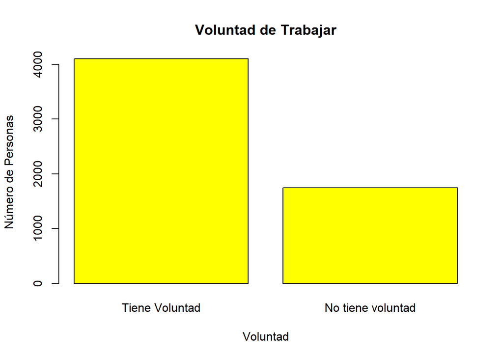

p209h: Se pregunta al encuestado si cumpliendo con sus obligaciones actuales de trabajo tiene la voluntad de trabajar más horas y además si estuvo disponible para poder hacerlo. De los encuestados, el 35.64% sí tuvieron la voluntad de trabajar más horas, mientras que el 15.15% no. Se ve de manera simple y clara que la mayoría tiene voluntad para trabajar más horas de lo común.

p223a1, p223a2, p223a3, p223a4, p223a5, p223a6, p223a7: Se les pregunta a los encuestados si presentan alguna limitación o dificultad física, mental, intelectual o de los sentidos (vista, oído, tacto, olfato, gusto) de forma permanente, que le impida desarrollarse normalmente en sus actividades diarias. Cada variable representa una pregunta de distintas limitaciones, que serán respondidas mediante un si o no. De los encuestados, el 96.97% no presenta ninguna discapacidad. No obstante, el resto respondió que sí como mínimo a alguna pregunta (variable) sobre la discapacidad.

### Patrones

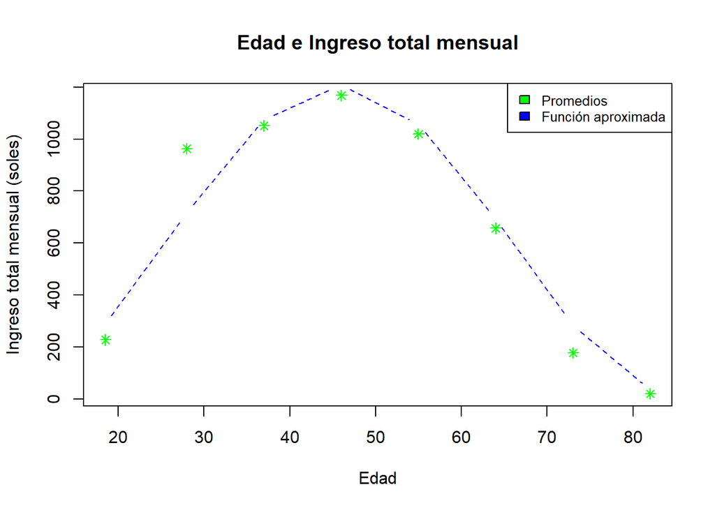

La siguiente función aproxima el comportamiento de la relación entre las variables:

$f(x)=600sen(\frac{\pi}{40}x-8.3)+610$ $\\\\ ;\ x\in [14;86]$

En la gráfica superior se muestra la relación entre la variable ingreso total mensual (ITotal) que representará la variable dependiente “y” y la variable Edad (p108) que será la variable independiente “x”. Asimismo, la gráfica muestra que la edad donde se suele ganar un mayor sueldo es aproximadamente a los 45 años, mientras que al comienzo y al final de la vida laboral se suele ganar menos a diferencia de su otras etapas laborales. Esta tendencia se da, ya que al principio de la vida laboral los jóvenes no tienen experiencia, por lo que ocupan cargos de bajo alcance. Asimismo, al final de la vida laboral, el rendimiento de las personas mayores se ve afectado por su edad, por lo que muchos se jubilan y reciben un sueldo menor al previo.

La variable que representa el ingreso total tiene datos mucho más dispersos a comparación de la edad, ya que la primera tiene un coeficiente de variación de 1.9, mientras que la segunda, que aún representa una muestra muy heterogénea, tiene un coeficiente de variación de 0.44.

Se optó por usar el coeficiente de variación en lugar de otro descriptor de dispersión, ya que las variables comparadas difieren en sus unidades y este analiza más que solo los datos a los extremos. Sin embargo, podemos utilizar el rango para complementar el análisis del coeficiente de variación, ya que los datos de la edad solo varían en 84 años mientras que los del ingreso total en 40000 soles.

Esta función trigonométrica es válida en el intervalo de 14 a 86 años de edad, debido a que el resto de edades no se ajustan a la función sinusoidal mostrada.

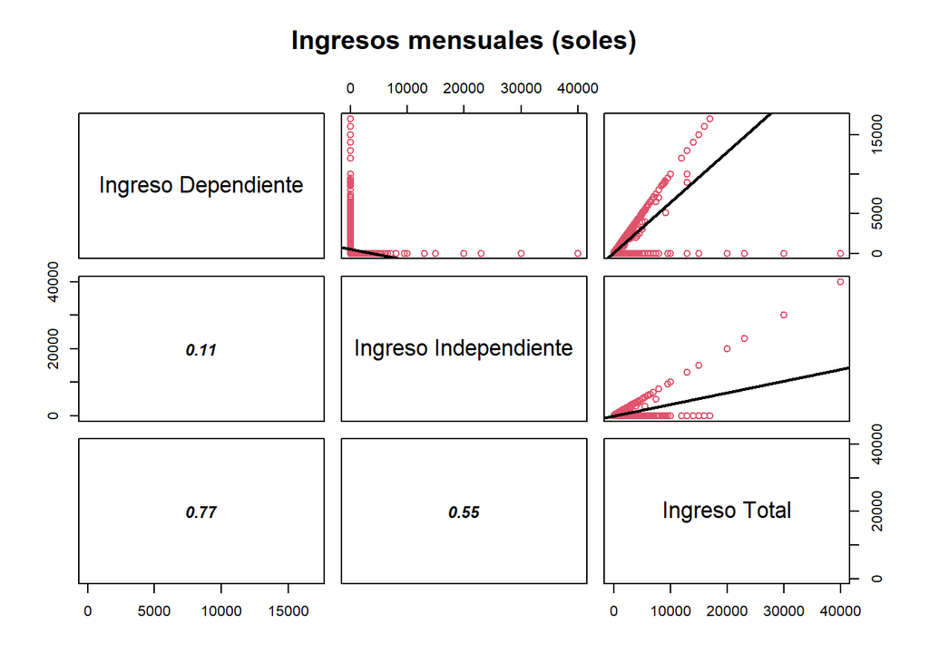

Función Ingreso Dependiente e Ingreso Independiente:

$f(x)=-0.14x+549.32$ $\\\\ ;\ x\in [0;40000]$

Función Ingreso Total e Ingreso Dependiente:

$g(x)=0.64x+38.63$ $\\\\ ;\ x\in [0;40000]$

Función Ingreso Total e Ingreso Independiente:

$h(x)=0.86x+555.70$ $\\\\ ;\ x\in [0;40000]$

Los ingresos totales que pueden tener las personas pueden ser de manera general, mediante un trabajo dependiente, un trabajo independiente o de ambos. Por ello, planteamos obtener una relación para obtener el ingreso total en función del ingreso dependiente e independiente.

Se puede ver que el ingreso mensual en soles obtenido del trabajo dependiente y el ingreso mensual total tienen una correlación positiva de 0.77. El ingreso mensual independiente y el ingreso total también tienen una correlación positiva pero menor, de 0.55. Esto se debe a que la suma de ambos constituyen el ingreso total mensual, pero más personas tienen trabajo dependiente que independiente. Por eso, el trabajo dependiente influye en mayor manera al ingreso total mensual.

Igualmente, se puede observar en la gráfica que los ingresos dependientes e independientes no tienen una relación directa. Esto se debe a que en la muestra, no hay personas que tengan ambos trabajos. Esto también se ve reflejado en la correlación entre ambas variables, la cual es -0.11. Es negativa, aunque en el gráfica se muestre positiva (muestra valor absoluto), ya que cuando uno crece el otro decrece. También, la correlación es muy cercana a cero, ya que casi no se relacionan debido a que cuando uno tiene un valor, el otro tiene 0 y viceversa.

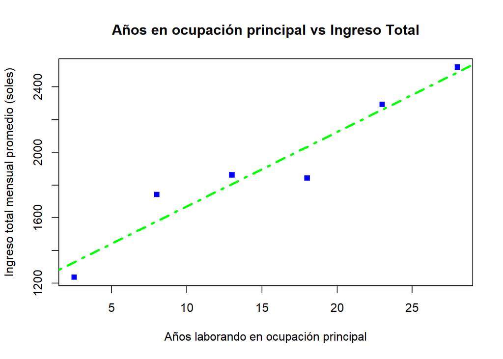

La siguiente función aproxima el comportamiento de la relación entre las variables:

$f(x)=45.48 x + 1215.27$ $; X\in [0;35]$

En la siguiente gráfica superior se muestra la relación entre la variable Ingreso total mensual promedio en soles (ITotal) que representará la variable dependiente “y” y la variable Años laborando en ocupación principal (p208b) que será la variable independiente “x”. Asimismo, establecemos la relación para verificar como una persona percibe su ingresos totales de forma mensual en función a la cantidad de años que una persona labora en su ocupación principal. La correlación entre los años que una persona ha trabajado en su ocupación principal y su ingreso total mensual es de 0.96. Esta alta correlación, se debe a que se han dividido los años en múltiples rangos y se ha promediado su ingreso total mensual para obtener una relación lineal evidente. También se han omitido las observaciones cuyos años laborando en su ocupación principal es de 36 a 46, ya que son pocas y difieren de la relación establecida.

La gráfica demuestra la tendencia de obtener un mayor ingreso total a medida que se ha trabajado más tiempo en la ocupación principal. Esto se debe a que a más años trabajando se tiene una mayor experiencia laboral ya que se ha podido subir en la escala de puestos dentro de una empresa, y ese amplio conocimiento sobre la misma empresa vale más.

Esta función lineal es válida en el intervalo de 0 a 35 años laborando en la ocupación principal, debido a que, como se mencionó anteriormente, no se está considerando datos superiores a 35 años laborando en su ocupación principal ya que no se ajustan a la función lineal encontrada.

### Modelos de Variables Aleatorias

[output not shown]

$$E(X)=
\frac{100}{0.6426}=155.62$$

### Descripción de variables

#### Variable

##### Ingreso total mensual

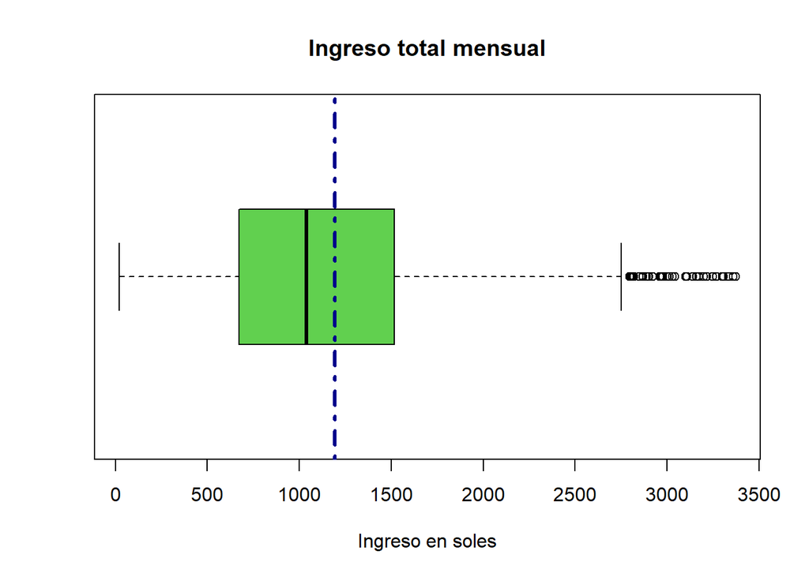

La variable ITotal representa los ingresos totales mensuales de los encuestados, el rango de esta variable es amplio, el cual es (20, 3373), por lo que consideramos que la data es variable a comparación de otras variables. Asimismo, el boxplot se muestra de manera horizontal para poder apreciar el rango de la variable de mejor manera. Finalmente, se utilizó estimación puntual para determinar la media muestral la cual es 1192.17 soles.

### Pruebas de Hipótesis

#### HIPÓTESIS I

$H_0:$ El ingreso mensual promedio de las personas mayores de edad económicamente activas es **mayor o igual** al sueldo mínimo.

$H_{0}:µ >= 930$

$H_1:$ El ingreso mensual promedio de las personas mayores de edad económicamente activas es **menor** al sueldo mínimo.

$H_{1}:µ < 930$

Nivel de confianza= 95%  
Los datos están muy dispersos. Esto se puede ver en el rango de la variable, que va de 20 a 3373, por lo que se prioriza una mayor confianza sobre una mayor precisión.  
Error=16.66  
Tamaño de la muestra= 4948

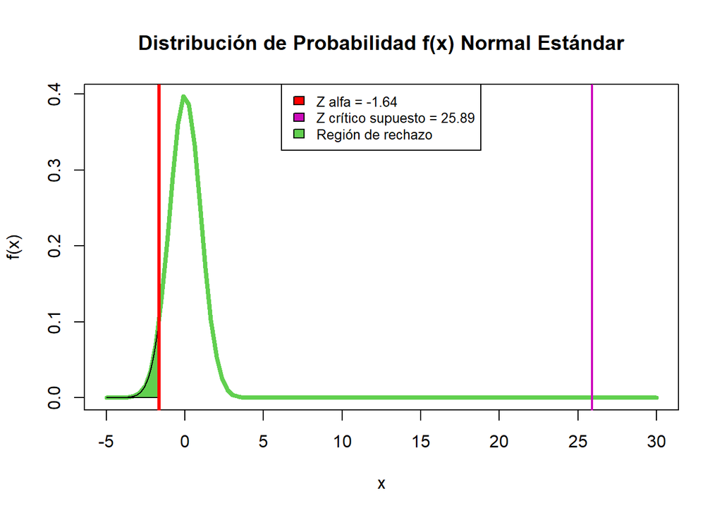

#### Intervalo de confianza para la hipótesis 1

Intervalo de confianza: [1175.51, $\infty$>

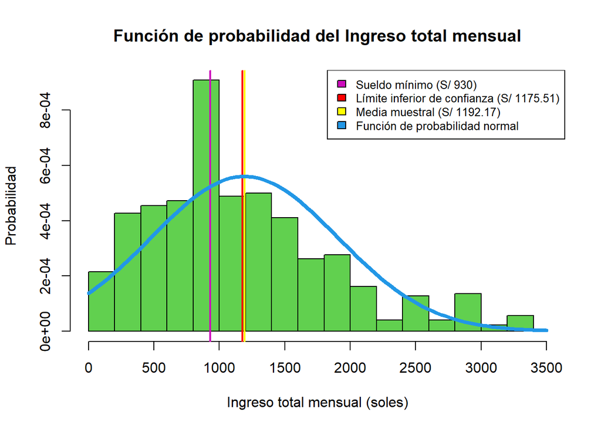

### Horas trabajadas semanales

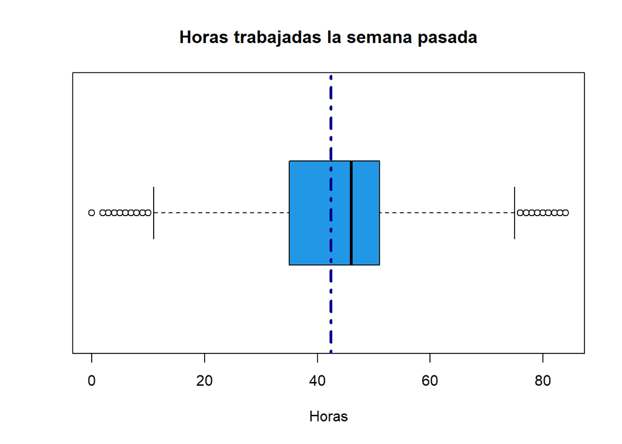

La variable p209t representa las horas totales trabajadas de los encuestados, el rango de esta variable no es amplio, este es (0, 84), por lo que consideramos que la data no es variable a comparación de las demás. Asimismo, el boxplot mostrado de manera horizontal nos sirve para poder visualizar el rango completo de la data de manera ordenada. Finalmente, se utilizó estimación puntual para hallar la media muestral. Esta es 42.41 horas.

### HIPÓTESIS 2

Ho = Las horas promedio de trabajo semanales de las personas son **menor o igual** a 48 horas.

$H_{0}:µ <= 48$

H1 = Las horas promedio de trabajo semanales de las personas son **mayor** a 48 horas.

$H_{1}:µ > 48$

Nivel de confianza= 80%  
Debido a que los datos no están muy dispersos, lo cual se justifica analizando el rango de la variable, que va de 0 a 84 horas, se prioriza una mayor precisión sobre una mayor confianza.  
Error=0.2  
Tamaño de la muestra= 5459

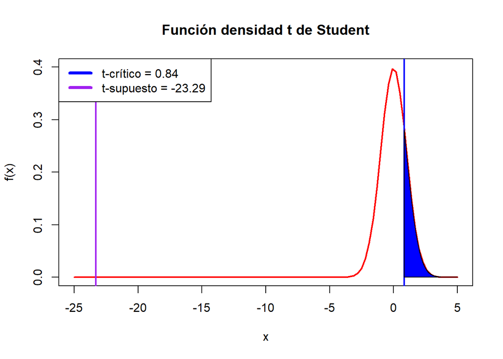

#### Intervalo de confianza para la hipótesis 2

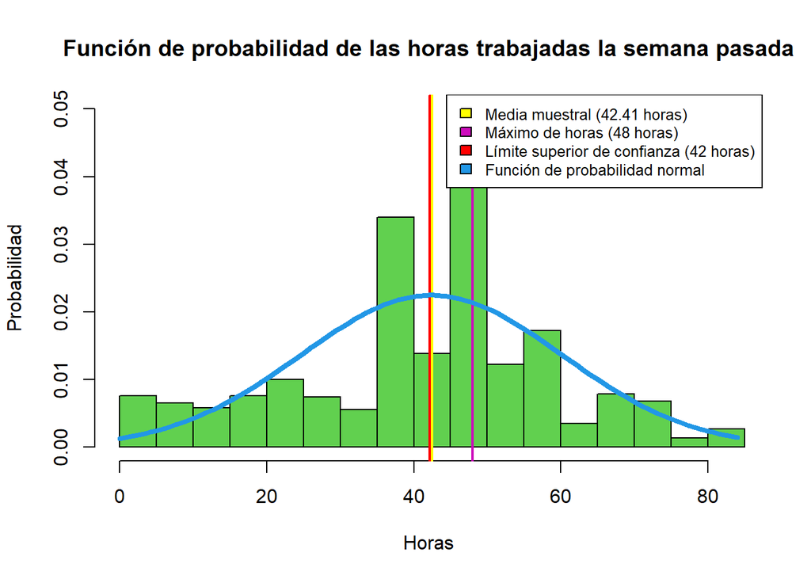

#### Variable: Ingreso Total

De población económicamente activa, por sexos.

[figure not shown]

A continuación, se analizará la variable de ingreso mensual total de hombres y mujeres. Podemos ver que la estimación puntual de la media del ingreso de los hombres es mayor a la de las mujeres. De igual manera, se puede apreciar mediante el boxplot que la caja de bigotes de los hombres se encuentra hacia la derecha en relación a la caja de bigotes de las mujeres. Esto nos da a entender que los ingresos totales del género masculino en general son mayores que los ingresos mensuales de las féminas.

### HIPÓTESIS 3

Ho = El ingreso mensual promedio de los hombres en Lima Metropolitana es **menor o igual** al ingreso mensual promedio de las mujeres.  
$H_{0}:µ_{1} <= µ_{2}$

H1 = El ingreso mensual promedio de los hombres en Lima Metropolitana es **mayor** al ingreso mensual promedio de las mujeres.  
$H_{0}:µ_{1} > µ_{2}$

Nivel de confianza= 95%

Debido a que los datos están muy dispersos (rango hombres: 33, 3504 y rango mujeres:15, 3100), por lo que se prioriza una mayor confianza sobre una mayor precisión.

Error=32.61.

Tamaño de la muestra= hombres:2879 y mujeres:2133.

Límite superior de confianza en x: 359.427.

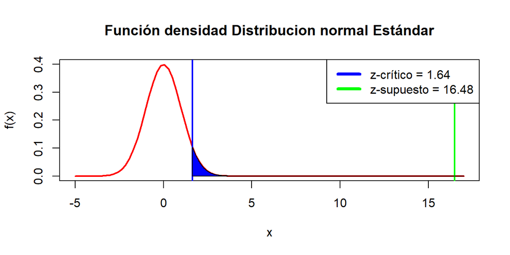

#### Conclusión hipótesis 3

Según el análisis de la variable ingreso mensual promedio en Lima Metropolitana, el valor de z-crítico es 1.64. Asimismo, el valor z supuesto es 16.48 y se ubica en la zona de rechazo. Finalmente, la hipótesis nula se rechaza, razón por la cual no se procede a graficar el intervalo de confianza como en las 2 hipótesis anteriores.

### Regresión 1

En la siguiente regresión se muestra la relación entre la variable ingreso total mensual (ITotal) que representará la variable dependiente “y” y la variable Años laborando en ocupación principal (p208b3) que será la variable independiente “x”.

#### Correlación entre las variables

La correlación entre las variables es 0.84, la cual es positiva y cercana a 1. Esto indica que presentan una proporcionalidad directa o positiva. Se considera que la correlación entre estas variables es fuerte ya que es mayor a 0.7.

#### Coeficientes de regresión

Se aplica la función lm, que ajusta una nube de puntos a un modelo lineal.

$y(x)=1348.29+39.56x$ $\\\\ ;\ x\in [3;31]$

#### R cuadrado

El R-cuadrado es 0.71, el cual es mayor a 0.7, es decir, cercano a 1, indica un buen ajuste del modelo lineal a los datos. Pues, se logra explicar gran parte de la variación total del ingreso total.

#### Prueba de hipótesis para el Intercepto (ßo)

Ho: ßo = 0  
H1: ßo ≠ 0

Con un α = 0.05 mayor que el p-valor = 0.000494 podemos rechazar la Ho, por lo tanto, ßo es diferente de cero.

Ho: ß1 = 0  
H1: ß1 ≠ 0

Con un α = 0.05 mayor que el p-valor = 0.008414 podemos rechazar la Ho, por lo tanto, ß1 es diferente de cero.

#### Gráfica de Regresión

La variable independiente “x” son los años laborando en ocupación principal (p208b3) y la variable dependiente “y” es el ingreso total mensual promedio (ITotal).

[figure not shown]

Se utilizó este modelo de regresión lineal, puesto que se consideró que a medida que un trabajador incrementa sus años laborando su ingreso total mensual tiende a aumentar. Esto se puede deber a que al mantenerse tantos años en un trabajo, esa persona genera valor para su empresa al no solo tener mayor experiencia laboral, si no un mayor conocimiento sobre la empresa. Asimismo, se estableció a “x” como la variable independiente que representa los años de un trabajador en su ocupación principal, ya que los trabajadores pueden decidir sobre esta. Por ejemplo, pueden decidir no trabajar durante un periodo de tiempo o no. En cambio, a diferencia de la otra variable (ingreso total), el trabajador no puede manipularla, puesto que normalmente es la administración quien define su salario y dependiendo de este podrá tener un mayor ingreso total mensual o no. Finalmente, analizamos el p-valor del modelo (0.008414) que al ser menor a la significancia (0.05), podemos concluir que el modelo es significativo.

#### Gráfica de error de regresión

$e=y_i-(1348.29+39.56x_i)$ $\\\\ ;\ x_{i}\in [3;31]$

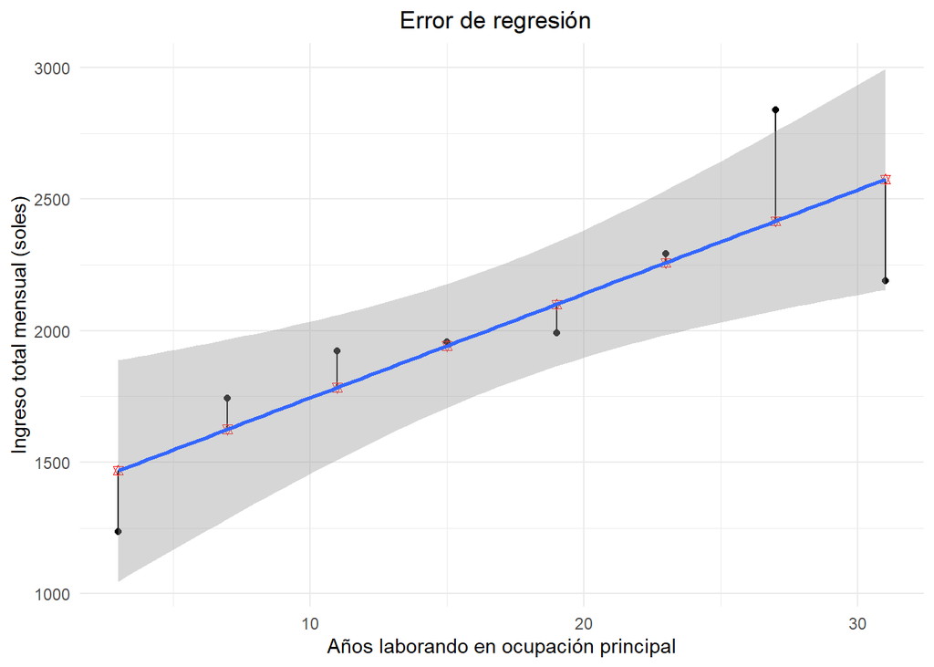

#### Calculando el error de regresión tomando valores de la muestra

Para hallar un error promedio de regresión se tomaron diez observaciones de la muestra aleatoriamente. De dichas muestras se tomaron los años laborando en la ocupación principal de cada encuestado y este dato se evaluó en la función de regresión calculada. Luego, se comparó el valor obtenido con el ingreso total real de dicho encuestado. Finalmente, el error promedio de regresión es: 556.86.

### Regresión 2

La variable ‘años trabajando en la ocupación principal’ (p208b3) representará la variable dependiente “y” y la variable ‘edad’ (p108) será la variable independiente “x”.

#### Correlación entre las variables

La correlación entre las variables es 0.99, la cual es positiva y cercana a 1. Esto indica que presentan una proporcionalidad directa o positiva.

#### Coeficientes de regresión

Se extraen los coeficientes **estimados** para el intercepto (ßo) y para la variable x (ß1).  
ßo = -5.79  
ß1 = 0.29  
$y(x)=ß_0+ß_1x$

$y(x)=-5.79 +0.29x$ $\\\\ ;\ x\in [18;72]$

#### Prueba de hipótesis para el Intercepto (ßo)

Ho: ßo = 0  
H1: ßo ≠ 0

Con un α = 0.05 mayor que el p-valor = 7.30e-05 podemos rechazar la Ho, por lo tanto, ßo es diferente de cero.

#### Prueba de hipótesis para el coeficiente de edad (ß1)

Ho: ß1 = 0  
H1: ß1 ≠ 0

Con un α = 0.05 mayor que el p-valor = 2.27e-07 podemos rechazar la Ho, por lo tanto, ß1 es diferente de cero.

#### R cuadrado

El R-cuadrado es 0.98 y como es cercano a 1 indica un buen ajuste del modelo lineal a los datos.

#### Gráfica de Regresión

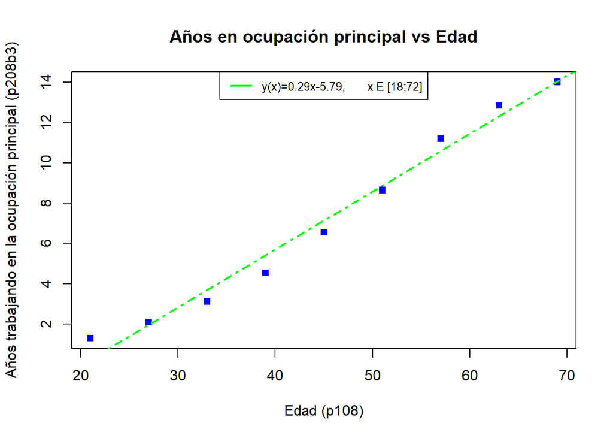

Se utilizó este modelo de regresión lineal, puesto que se consideró que a medida que un trabajador incrementa sus años de trabajo en su ocupación principal también su edad aumenta. Esto puede suceder, ya que es razonable que una persona pueda permanecer en una empresa debido a los beneficios que esta le pueda ofrecer. Asimismo, los trabajadores suelen buscar estabilidad laboral en un trabajo, por ende estos suelen permanecer una mayor cantidad de años en el. Finalmente, es evidente que la edad de una persona es independiente de los años que lleva trabajando en su ocupación principal. Además, analizamos el p-valor del modelo (2.271e-07) que al ser menor a la significancia (0.05), podemos concluir que el modelo es significativo.

#### Gráfica de error de regresión

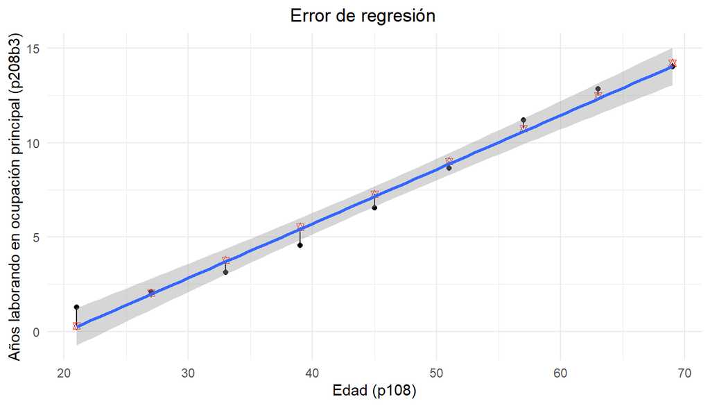

#### Calculando el error de regresión tomando valores de la muestra

Para hallar un error promedio de regresión se tomaron mil observaciones de la muestra aleatoriamente. De dichas muestras se tomó la edad de cada encuestado y este dato se evaluó en la función de regresión calculada. Luego, se comparó el valor obtenido con los años laborando en su ocupación principal reales de dicho encuestado. Finalmente, el error promedio de regresión es: 3.83.

### Regresión 3

La variable ‘Ingreso total mensual promedio’ (ITotal) representará la variable dependiente “y” y la variable ‘Horas semanales’ (p209t) será la variable independiente “x”.

#### Correlación entre las variables

La correlación entre las variables es 0.98, la cual es positiva y cercana a 1. Esto indica que presentan una proporcionalidad directa o positiva.

#### Coeficientes de regresión

Se aplica la función **summary** a la variable de regresión y se extraen los coeficientes **estimados** para el intercepto (ßo) y para la variable x (ß1).

ßo = 105.367  
ß1 = 29.568

$y(x)=ß0+ß1x$  
$y(x)=105.367+29.568x$

#### Prueba de hipótesis para el Intercepto (ßo)

Ho: ßo = 0  
H1: ßo ≠ 0

Con un α = 0.15 mayor que el p-valor = 0.128 podemos rechazar la Ho, por lo tanto, ßo es diferente de cero. Tomamos este valor de alfa ya que el modelo de regresión debe tener este intercepto para reflejar el comportamiento de las variables en la muestra y poder realizar las pruebas que se mostrarán posteriormente.

Ho: ß1 = 0  
H1: ß1 ≠ 0

Con un α = 0.15 mayor que el p-valor = 2.7e-05 podemos rechazar la Ho, por lo tanto, ß1 es diferente de cero.

#### R cuadrado

Se tiene un R-cuadrado de 0.96, el cual indica un buen ajuste del modelo lineal a los datos ya que es mayor a 0.7, cercano a 1.

#### Gráfica de regresión

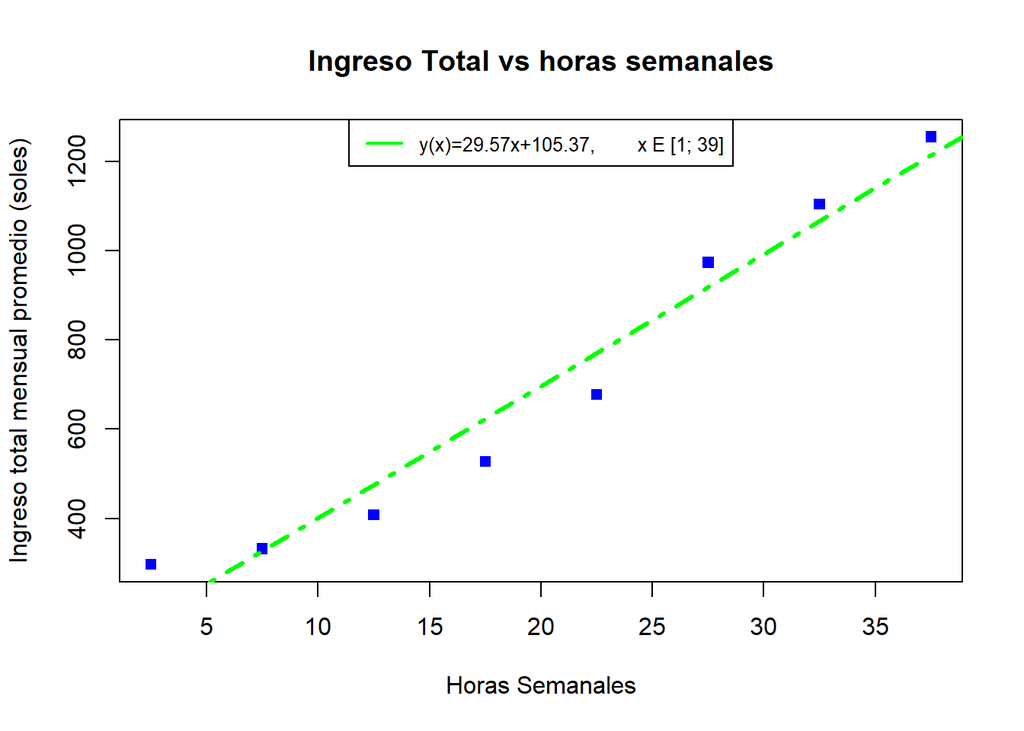

Se utilizó este modelo de regresión lineal, puesto que se consideró que el Ingreso total mensual promedio en soles incrementa en medida que realice un trabajo por una mayor cantidad de horas semanales. Esto puede suceder, ya que la persona puede decidir cuantas horas desea trabajar durante una semana y esto se verá reflejado en el pago que la empresa o trabajo, donde labora, podría realizarle en base a ese periodo de tiempo. Finalmente, los trabajadores también pueden tomar decisiones sobre la variable independiente “x”, ya que pueden decidir si trabajar menos o más horas durante la semana. Además, analizamos el p-valor del modelo (2.698e-05) que al ser menor a la significancia (0.15), podemos concluir que el modelo es significativo.